# act_report

## Data Analysis and Insights

###### # Loading required modules

```python
import pandas as pd
import numpy as np
```

```python
import matplotlib.pyplot as plt
from matplotlib import rcParams
import seaborn as sb
import matplotlib
```

```python
%matplotlib inline
rcParams['figure.figsize'] = 8,4
sb.set_style('whitegrid')
```

###### # Loading 'twitter_archive_master.csv' Data File

```python
dtypes = {'tweet_id': np.str,'source':'category','in_reply_to_status_id':np.str,'in_reply_to_user_id':np.str}
twitter_archive_master = pd.read_csv("twitter_archive_master.csv",encoding="utf-8", dtype=dtypes,parse_dates=['timestamp'])
```

**I observer athat above dataset could be considered as following parts**:-

unique features:

- tweet_id
- timestamp
- text
- expanded_urls
- jpg_url

features those could be used as a category:

- source
- type
- stage

features with numeric values:

- rating_numerator
- rating_denominator
- retweet_count
- favorite_count

others remaining features:

- name
- in_reply_to_status_id
- in_reply_to_user_id

*And this part would help us to apply proper analizing tool on the given dataset.*

```python
twitter_archive_master.describe()
```

|  | rating_numerator | rating_denominator | retweet_count | favorite_count |
| --- | --- | --- | --- | --- |
| count | 1498.000000 | 1498.0 | 1499.000000 | 1499.000000 |
| mean | 10.903725 | 10.0 | 2740.285524 | 9185.482322 |
| std | 1.726463 | 0.0 | 4770.986337 | 12853.229875 |
| min | 2.000000 | 10.0 | 13.000000 | 80.000000 |
| 25% | 10.000000 | 10.0 | 633.500000 | 2139.000000 |
| 50% | 11.000000 | 10.0 | 1403.000000 | 4399.000000 |
| 75% | 12.000000 | 10.0 | 3156.500000 | 11512.000000 |
| max | 14.000000 | 10.0 | 77699.000000 | 143896.000000 |

'rating_denominator' is 10.0 , no surprise is there!

We can see median 'retweet_count' value is 1403 and median 'favorite_count' value is 4399.

```python
twitter_archive_master.corr()
```

|  | rating_numerator | rating_denominator | retweet_count | favorite_count |
| --- | --- | --- | --- | --- |
| rating_numerator | 1.000000 | NaN | 0.334656 | 0.440732 |
| rating_denominator | NaN | NaN | NaN | NaN |
| retweet_count | 0.334656 | NaN | 1.000000 | 0.913633 |
| favorite_count | 0.440732 | NaN | 0.913633 | 1.000000 |

```python
twitter_archive_master.retweet_count.corr(twitter_archive_master.favorite_count,method="pearson")
```

```
0.91363307648481629
```

By Default .corr() function using a linear correlation method : "pearson".

From the above correlation table we can found that strongest valuable correlation exist between 'favorite_count' & 'retweet_count'. Their corr value is 0.913633

Where correlation between 'rating_numerator' & 'retweet_count' is 0.334656 .And correlation between 'rating_numerator' & 'favorite_count' is 0.440732

```python
twitter_archive_master.groupby(["source"])["tweet_id","in_reply_to_status_id","in_reply_to_user_id","name","stage"].count()
```

| source | tweet_id | in_reply_to_status_id | in_reply_to_user_id | name | stage |
| --- | --- | --- | --- | --- | --- |
| <a href="http://twitter.com" rel="nofollow">Twitter Web Client</a> | 20 | 0 | 0 | 7 | 1 |
| <a href="http://twitter.com/download/iphone" rel="nofollow">Twitter for iPhone</a> | 1472 | 14 | 14 | 902 | 227 |
| <a href="https://about.twitter.com/products/tweetdeck" rel="nofollow">TweetDeck</a> | 7 | 0 | 0 | 5 | 1 |

From the above pivot table we can say,for maximum cases @dog_rates used iPhone to make tweets in twitter.

And for all 14 times when @dog_rates had used iPhone as a source device to reply to a user or a status.

```python
twitter_archive_master.groupby(["stage"])['rating_numerator','retweet_count','favorite_count'].min()
```

| stage | rating_numerator | retweet_count | favorite_count |
| --- | --- | --- | --- |
| doggo | 5.0 | 702 | 2542 |
| floofer | 10.0 | 487 | 2220 |
| pupper | 7.0 | 100 | 673 |
| puppo | 9.0 | 695 | 3218 |

```python
twitter_archive_master.groupby(["stage"])['rating_numerator','retweet_count','favorite_count'].max()
```

| stage | rating_numerator | retweet_count | favorite_count |
| --- | --- | --- | --- |
| doggo | 14.0 | 77699 | 128712 |
| floofer | 13.0 | 17993 | 32771 |
| pupper | 14.0 | 36662 | 124640 |
| puppo | 14.0 | 49381 | 143896 |

From the last 2 tables we can say dog stage : 'doggo' has the lowest 'rating_numerator' of 5.0

On the other hand, highest 'rating_numerator' for all dog stages are same(14.0) except stage : 'floofer'

```python
twitter_archive_master.groupby(["stage"])['retweet_count','favorite_count'].agg(['count','min','max','sum','mean','median','std'])
```

| stage | retweet_count count | retweet_count min | retweet_count max | retweet_count sum | retweet_count mean | retweet_count median | retweet_count std | favorite_count count | favorite_count min | favorite_count max | favorite_count sum | favorite_count mean | favorite_count median | favorite_count std |
| --- | --- | --- | --- | --- | --- | --- | --- | --- | --- | --- | --- | --- | --- | --- |
| doggo | 57 | 702 | 77699 | 408769 | 7171.385965 | 2604.0 | 13187.451990 | 57 | 2542 | 128712 | 1131623 | 19853.035088 | 11502.0 | 22981.619895 |
| floofer | 7 | 487 | 17993 | 33876 | 4839.428571 | 3171.0 | 5993.850348 | 7 | 2220 | 32771 | 90841 | 12977.285714 | 11090.0 | 11076.351385 |
| pupper | 147 | 100 | 36662 | 368956 | 2509.904762 | 1164.0 | 4036.357145 | 147 | 673 | 124640 | 1176484 | 8003.292517 | 3327.0 | 12961.498717 |
| puppo | 18 | 695 | 49381 | 121359 | 6742.166667 | 2439.5 | 11651.240020 | 18 | 3218 | 143896 | 421597 | 23422.055556 | 11112.5 | 33671.392175 |

From the above table we can see, dog stage name 'pupper' has the lowest amount of 'retweet_count' & 'favorite_count' 100 & 673 respectively.

On the other hand stage : 'doggo' has the highest 'retweet_count' of 77699 retweets. And stage : 'puppo' has the highest 'favorite_count' of 143896 favorites(likes).

Also we can see that stage : 'pupper' has the lowest mean value for 'retweet_count' & 'favorite_count' respectively 2509.90 and 8003.29 .Another thing to point out count value(147) for pupper is maximum along all other stages. That might be the cause of low mean values.

```python
twitter_archive_master.groupby(["stage","type"])['retweet_count','favorite_count'].mean()
```

| stage | type | retweet_count | favorite_count |
| --- | --- | --- | --- |
| doggo | Bedlington_terrier | 1859.500000 | 8897.000000 |
|  | Blenheim_spaniel | 1084.000000 | 4156.000000 |
|  | Border_collie | 2448.000000 | 9225.000000 |
|  | Chesapeake_Bay_retriever | 4270.000000 | 12158.000000 |
|  | Chihuahua | 3236.000000 | 16215.000000 |
|  | Dandie_Dinmont | 2002.000000 | 8108.000000 |
|  | English_springer | 3367.000000 | 16887.000000 |
|  | Eskimo_dog | 51130.000000 | 73643.000000 |
|  | German_shepherd | 3173.333333 | 15646.333333 |
|  | German_short-haired_pointer | 702.000000 | 2542.000000 |
|  | Great_Dane | 4093.000000 | 11502.000000 |
|  | Great_Pyrenees | 6716.000000 | 22949.000000 |
|  | Irish_setter | 4910.000000 | 12834.000000 |
|  | Labrador_retriever | 15004.166667 | 31027.666667 |
|  | Norwegian_elkhound | 3552.000000 | 12984.000000 |
|  | Old_English_sheepdog | 1706.000000 | 9889.000000 |
|  | Pembroke | 5060.000000 | 22108.500000 |
|  | Pomeranian | 4628.500000 | 18170.500000 |
|  | Siberian_husky | 2128.000000 | 10144.000000 |
|  | Staffordshire_bullterrier | 5697.000000 | 20517.500000 |
|  | beagle | 3365.000000 | 8135.000000 |
|  | borzoi | 2503.000000 | 6336.000000 |
|  | boxer | 2464.000000 | 14321.000000 |
|  | briard | 6290.000000 | 18265.000000 |
|  | cocker_spaniel | 2018.500000 | 9174.500000 |
|  | dalmatian | 1801.500000 | 6818.500000 |
|  | flat-coated_retriever | 18806.000000 | 47127.000000 |
|  | golden_retriever | 6591.769231 | 19470.615385 |
|  | komondor | 3540.000000 | 20420.000000 |
|  | standard_poodle | 41176.000000 | 93977.000000 |
| ... | ... | ... | ... |
| pupper | dalmatian | 1465.000000 | 8336.000000 |
|  | golden_retriever | 2322.375000 | 7582.562500 |
|  | keeshond | 1092.000000 | 2824.000000 |
|  | kelpie | 3006.500000 | 8690.000000 |
|  | kuvasz | 1388.500000 | 4724.500000 |
|  | malamute | 989.000000 | 2845.000000 |
|  | miniature_pinscher | 698.500000 | 2307.500000 |
|  | miniature_poodle | 1919.000000 | 3877.000000 |
|  | mix | 1279.666667 | 3341.000000 |
|  | papillon | 1070.666667 | 3732.666667 |
|  | pug | 872.625000 | 2126.625000 |
|  | redbone | 3715.000000 | 8482.000000 |
|  | schipperke | 986.000000 | 3176.000000 |
|  | toy_poodle | 1948.400000 | 6158.200000 |
|  | vizsla | 1623.000000 | 7322.000000 |
|  | whippet | 431.000000 | 1246.000000 |
| puppo | Airedale | 1705.000000 | 6991.000000 |
|  | American_Staffordshire_terrier | 1329.000000 | 5807.000000 |
|  | Cardigan | 10685.000000 | 34903.000000 |
|  | Eskimo_dog | 2336.333333 | 11103.000000 |
|  | German_shepherd | 3156.000000 | 11208.000000 |
|  | Labrador_retriever | 3909.000000 | 11141.000000 |
|  | Lakeland_terrier | 49381.000000 | 143896.000000 |
|  | Old_English_sheepdog | 695.000000 | 3218.000000 |
|  | Pembroke | 10188.000000 | 48275.000000 |
|  | Rottweiler | 19279.000000 | 56373.000000 |
|  | chow | 1720.000000 | 5475.000000 |
|  | golden_retriever | 1960.500000 | 17149.000000 |
|  | malamute | 1333.000000 | 4545.000000 |
|  | miniature_pinscher | 3140.000000 | 11017.000000 |

116 rows × 2 columns

```python
twitter_archive_master.groupby(["stage","type"])['retweet_count','favorite_count'].mean().max()
```

```
retweet_count      51130.0
favorite_count    143896.0
dtype: float64
```

```python
twitter_archive_master.groupby(["stage","type"])['retweet_count','favorite_count'].mean().idxmax()
```

```
retweet_count           (doggo, Eskimo_dog)
favorite_count    (puppo, Lakeland_terrier)
dtype: object
```

From the last 3 tables , we found that

Dog stage : doggo & Dog type : Eskimo_dog has the highest mean value for 'retweet_count' : 51130

Dog stage : puppo & Dog type : Lakeland_terrier has the highest mean value for 'favorite_count' : 143896

### Data Visualization

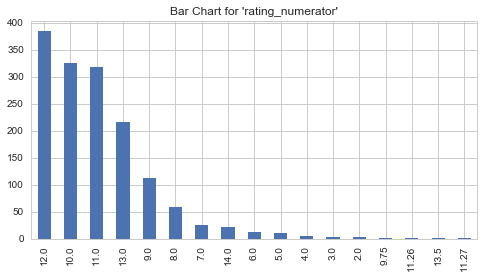

```python
twitter_archive_master.rating_numerator.value_counts().plot(kind="bar",title = "Bar Chart for 'rating_numerator'")
```

From the above bar-chart, we can see most frequent 'rating_numerator' is 12.0 and its occurred more than 375 times.

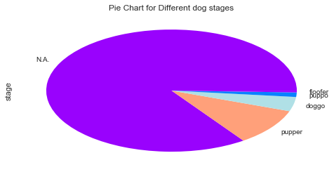

```python
color_theme = ['#9902FD', '#FFA07A', '#B0E0E6','#0981FF']
twitter_archive_master.stage.fillna("N.A.").value_counts().plot(kind="pie",colors=color_theme,title="Pie Chart for Different dog stages")
```

From the above pie-chart , we can see dog stage : 'pupper' has the 2nd highest share after stage : N.A.(Not Available)

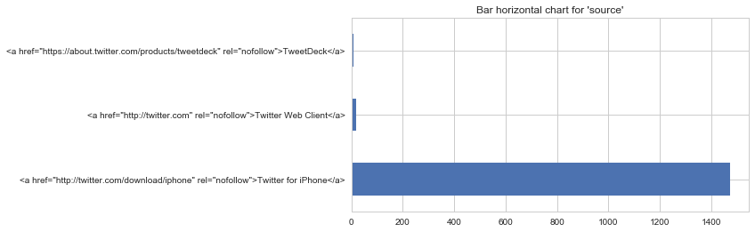

```python
twitter_archive_master.source.value_counts().plot(kind="barh",title="Bar horizontal chart for 'source'")
```

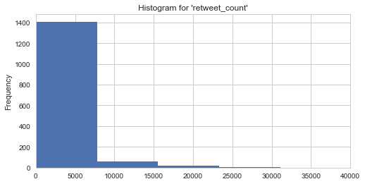

```python
twitter_archive_master.retweet_count.plot(kind="hist",title="Histogram for 'retweet_count'",xlim=(0,40000))
```

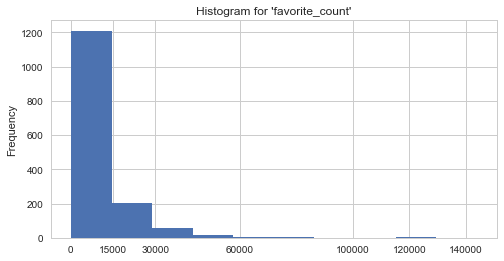

```python
twitter_archive_master.favorite_count.plot(kind="hist",title= "Histogram for 'favorite_count'",xticks=[0,15000,30000,60000,100000,120000,140000])
```

So from the above Histogram we can say, that maximum number of 'favorite_count' exist between 0 to 15000. Also we can see an outlier.

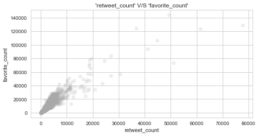

```python
twitter_archive_master.plot(kind="scatter",x="retweet_count",y="favorite_count",c=["darkgrey"],s=50,alpha=0.2,title = "'retweet_count' V/S 'favorite_count'")
```

Above scatterplot showing relation between 'retweet_count' & 'favorite_count' .And It is a strong relationship as like we have already computed correlation of 0.913633

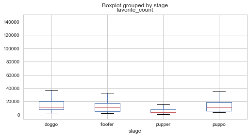

```python
twitter_archive_master.boxplot(column="favorite_count",by="stage")
```

```python
twitter_archive_master.groupby(["stage"])["favorite_count"].median()
```

```
stage
doggo      11502.0
floofer    11090.0
pupper      3327.0
puppo      11112.5
Name: favorite_count, dtype: float64
```